# ROC 曲线与 cutoff 建立

hiox-tech

2026-08-06

# 1 分析目的

受试者工作特征（receiver operating characteristic，ROC）曲线评价定量指标区分阳性与阴性结局的能力， 常用于建立诊断截断值（cutoff）。`ivdtools` 的 `roc()` 提供渐进式工作流：`roc()` 创建对象 → `describe()` → `auc()`（AUC 与置信区间）→ `cutoff()`（Youden 与最近拐角最优截断值）→ `plot()` 与 `summary()`。

本文以一个完整的单标记物示例演示 ROC 分析全流程。参考变量必须是二分类；若原始参考为连续变量， 应先转二分类（参见《定性分析》中的 `continuous_to_binary()`）并记录阈值与阳性方向。

```r
library(ivdtools)
library(readr)
```

# 2 函数概述

| 函数 | 主要用途 | 关键输入或输出 |
| --- | --- | --- |
| `roc()` | 创建 ROC 对象 | `cols`、`reference`、`id`、`positive` |
| `describe()` | 标记物描述统计 | 参考强制按分类处理 |
| `auc()` | AUC 与置信区间 | 逐标记物 |
| `cutoff()` | 最优截断值 | Youden 与最近拐角，需先 `auc()` |
| `plot()` | ROC 曲线 | `cutpoint` 标出最优点 |
| `summary()` | 汇总 |  |

# 3 示例：单标记物 ROC 分析

## 3.1 读取和核验数据

```r
roc_dat <- read_csv("./data/roc-example.csv", show_col_types = FALSE)
roc_dat <- as.data.frame(roc_dat)
str(roc_dat)
```

```
#> 'data.frame':    100 obs. of  3 variables:
#>  $ sid: num  1 2 3 4 5 6 7 8 9 10 ...
#>  $ ref: num  0 0 0 0 0 0 0 0 0 0 ...
#>  $ x1 : num  7.59 8.31 5.89 5.59 9.57 ...
```

```r
table(roc_dat$ref)
```

```
#>
#>  0  1
#> 50 50
```

参考列 `ref` 为 0/1 二分类，正、负各 50 例。

## 3.2 创建对象与描述

```r
ro <- roc(roc_dat, cols = "x1", reference = "ref", id = "sid")
ro
```

```
#>
#> ROC Analysis
#>   Data class:        data.frame
#>   Total rows:        100
#>   Complete cases:    100
#>   Reference:         ref (binary)
#>   Positive / Neg:    50 / 50
#>   Evaluation cols:   1  (x1)
#>   Duplicate IDs:     none
#>
#> Analysis slots:
#>     [ ] Describe
#>     [ ] AUC
#>     [ ] Cutoff
#>     [ ] MLR
```

```r
ro <- describe(ro)
```

```
#>
#> Descriptive Statistics
#>   Variable               n     Mean       SD      Min       Q1   Median       Q3      Max  NA
#>   ---------------------------------------------------------------------------
#>   x1                   100   9.2576   4.4744  -0.3894   5.8224   8.5472  12.9591  18.7295
#>
#>   ref
#>   Level                Count  Percent
#>    --------------------------------------
#>   0                       50    50.0%
#>   1                       50    50.0%
```

> **参数说明：** `roc()` 的 `cols` 为定量标记物列；`reference` 为二分类参考列（数值 0/1、二水平 因子或二取值字符均可）；`positive` 指定阳性水平（不给出时默认取排序后的最后一个水平）。 每个标记物的方向（`geq`/`leq`）按阳性组均值自动判断。

## 3.3 AUC

```r
ro <- auc(ro)
```

```
#>
#> AUC Table
#>   Column               AUC          95% CI  Direction
#>   ------------------------------------------------------------
#>   x1                0.9420  [0.8940, 0.9900]       geq
```

```r
ro$auc_table
```

|  | Column | AUC | CI_lower | CI_upper | Direction |
| --- | --- | --- | --- | --- | --- |
| 1 | x1 | 0.9420 | 0.8940 | 0.9900 | geq |

标记物 x1 的 AUC ≈ 0.942（95% CI [0.894, 0.990]），区分能力较强。

## 3.4 最优截断值

```r
ro <- cutoff(ro)
```

```
#>
#> Optimal Cutoff Analysis
#>   Column: x1
#>     Youden / Corner: cutoff = 8.7617  (sens = 0.9000, spec = 0.9200, Youden = 0.8200)
#>
#>   Full cutoff table:
#>         Cutoff      Sens      Spec     TP    FP    TN    FN    Youden
#>   ----------------------------------------------------------------------
#>           -Inf    1.0000    0.0000     50    50     0     0    0.0000
#>        18.7295    0.0200    1.0000      1     0    50    49    0.0200
#>        18.5675    0.0400    1.0000      2     0    50    48    0.0400
#>        18.2248    0.0600    1.0000      3     0    50    47    0.0600
#>        17.7837    0.0800    1.0000      4     0    50    46    0.0800
#>        16.4453    0.1000    1.0000      5     0    50    45    0.1000
#>        15.8893    0.1200    1.0000      6     0    50    44    0.1200
#>        15.8087    0.1400    1.0000      7     0    50    43    0.1400
#>        15.6058    0.1600    1.0000      8     0    50    42    0.1600
#>        15.5003    0.1800    1.0000      9     0    50    41    0.1800
#>        15.2855    0.2000    1.0000     10     0    50    40    0.2000
#>        15.0168    0.2200    1.0000     11     0    50    39    0.2200
#>        14.8639    0.2400    1.0000     12     0    50    38    0.2400
#>        14.6980    0.2600    1.0000     13     0    50    37    0.2600
#>        14.4757    0.2800    1.0000     14     0    50    36    0.2800
#>        14.4469    0.3000    1.0000     15     0    50    35    0.3000
#>        14.4042    0.3200    1.0000     16     0    50    34    0.3200
#>        14.1952    0.3400    1.0000     17     0    50    33    0.3400
#>        14.1938    0.3600    1.0000     18     0    50    32    0.3600
#>        13.9382    0.3800    1.0000     19     0    50    31    0.3800
#>        13.7845    0.4000    1.0000     20     0    50    30    0.4000
#>        13.3718    0.4200    1.0000     21     0    50    29    0.4200
#>        13.0699    0.4400    1.0000     22     0    50    28    0.4400
#>        12.9970    0.4600    1.0000     23     0    50    27    0.4600
#>        12.9854    0.4800    1.0000     24     0    50    26    0.4800
#>        12.9659    0.5000    1.0000     25     0    50    25    0.5000
#>        12.9569    0.5200    1.0000     26     0    50    24    0.5200
#>        12.7812    0.5400    1.0000     27     0    50    23    0.5400
#>        12.7534    0.5600    1.0000     28     0    50    22    0.5600
#>        12.5227    0.5800    1.0000     29     0    50    21    0.5800
#>        12.3440    0.6000    1.0000     30     0    50    20    0.6000
#>        12.2962    0.6200    1.0000     31     0    50    19    0.6200
```

[output cut: 55 more lines]

```
#>         3.9552    0.9800    0.2400     49    38    12     1    0.2200
#>         3.9103    1.0000    0.2400     50    38    12     0    0.2400
#>         3.7719    1.0000    0.2200     50    39    11     0    0.2200
#>         3.5881    1.0000    0.2000     50    40    10     0    0.2000
#>         3.4583    1.0000    0.1800     50    41     9     0    0.1800
#>         3.4422    1.0000    0.1600     50    42     8     0    0.1600
#>         2.9673    1.0000    0.1400     50    43     7     0    0.1400
#>         2.9111    1.0000    0.1200     50    44     6     0    0.1200
#>         2.7698    1.0000    0.1000     50    45     5     0    0.1000
#>         2.5203    1.0000    0.0800     50    46     4     0    0.0800
#>         2.3646    1.0000    0.0600     50    47     3     0    0.0600
#>         2.2596    1.0000    0.0400     50    48     2     0    0.0400
#>         0.4733    1.0000    0.0200     50    49     1     0    0.0200
#>        -0.3894    1.0000    0.0000     50    50     0     0    0.0000
#>            Inf    0.0000    1.0000      0     0    50    50    0.0000
```

```r
print(ro$cutoff_table)
```

```
#>
#> Optimal Cutoff Analysis
#>   Column: x1
#>     Youden / Corner: cutoff = 8.7617  (sens = 0.9000, spec = 0.9200, Youden = 0.8200)
#>
#>   Full cutoff table:
#>         Cutoff      Sens      Spec     TP    FP    TN    FN    Youden
#>   ----------------------------------------------------------------------
#>           -Inf    1.0000    0.0000     50    50     0     0    0.0000
#>        18.7295    0.0200    1.0000      1     0    50    49    0.0200
#>        18.5675    0.0400    1.0000      2     0    50    48    0.0400
#>        18.2248    0.0600    1.0000      3     0    50    47    0.0600
#>        17.7837    0.0800    1.0000      4     0    50    46    0.0800
#>        16.4453    0.1000    1.0000      5     0    50    45    0.1000
#>        15.8893    0.1200    1.0000      6     0    50    44    0.1200
#>        15.8087    0.1400    1.0000      7     0    50    43    0.1400
#>        15.6058    0.1600    1.0000      8     0    50    42    0.1600
#>        15.5003    0.1800    1.0000      9     0    50    41    0.1800
#>        15.2855    0.2000    1.0000     10     0    50    40    0.2000
#>        15.0168    0.2200    1.0000     11     0    50    39    0.2200
#>        14.8639    0.2400    1.0000     12     0    50    38    0.2400
#>        14.6980    0.2600    1.0000     13     0    50    37    0.2600
#>        14.4757    0.2800    1.0000     14     0    50    36    0.2800
#>        14.4469    0.3000    1.0000     15     0    50    35    0.3000
#>        14.4042    0.3200    1.0000     16     0    50    34    0.3200
#>        14.1952    0.3400    1.0000     17     0    50    33    0.3400
#>        14.1938    0.3600    1.0000     18     0    50    32    0.3600
#>        13.9382    0.3800    1.0000     19     0    50    31    0.3800
#>        13.7845    0.4000    1.0000     20     0    50    30    0.4000
#>        13.3718    0.4200    1.0000     21     0    50    29    0.4200
#>        13.0699    0.4400    1.0000     22     0    50    28    0.4400
#>        12.9970    0.4600    1.0000     23     0    50    27    0.4600
#>        12.9854    0.4800    1.0000     24     0    50    26    0.4800
#>        12.9659    0.5000    1.0000     25     0    50    25    0.5000
#>        12.9569    0.5200    1.0000     26     0    50    24    0.5200
#>        12.7812    0.5400    1.0000     27     0    50    23    0.5400
#>        12.7534    0.5600    1.0000     28     0    50    22    0.5600
#>        12.5227    0.5800    1.0000     29     0    50    21    0.5800
#>        12.3440    0.6000    1.0000     30     0    50    20    0.6000
#>        12.2962    0.6200    1.0000     31     0    50    19    0.6200
```

[output cut: 55 more lines]

```
#>         3.9552    0.9800    0.2400     49    38    12     1    0.2200
#>         3.9103    1.0000    0.2400     50    38    12     0    0.2400
#>         3.7719    1.0000    0.2200     50    39    11     0    0.2200
#>         3.5881    1.0000    0.2000     50    40    10     0    0.2000
#>         3.4583    1.0000    0.1800     50    41     9     0    0.1800
#>         3.4422    1.0000    0.1600     50    42     8     0    0.1600
#>         2.9673    1.0000    0.1400     50    43     7     0    0.1400
#>         2.9111    1.0000    0.1200     50    44     6     0    0.1200
#>         2.7698    1.0000    0.1000     50    45     5     0    0.1000
#>         2.5203    1.0000    0.0800     50    46     4     0    0.0800
#>         2.3646    1.0000    0.0600     50    47     3     0    0.0600
#>         2.2596    1.0000    0.0400     50    48     2     0    0.0400
#>         0.4733    1.0000    0.0200     50    49     1     0    0.0200
#>        -0.3894    1.0000    0.0000     50    50     0     0    0.0000
#>            Inf    0.0000    1.0000      0     0    50    50    0.0000
```

`cutoff()` 给出全部候选截断值及对应的灵敏度、特异度、Youden 指数等，并用两种准则标记最优： **Youden**（最大化 `Se + Sp − 1`）与**最近拐角**（最小化到 (0,1) 的距离）。本例 Youden/Corner 最优截断值均为 8.76（灵敏度 0.90、特异度 0.92、Youden 0.82）。

## 3.5 图形与汇总

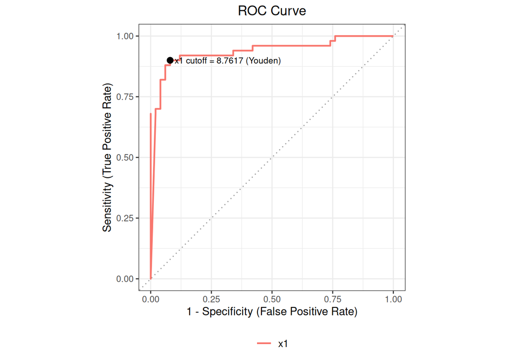

```r
plot(ro, cutpoint = "Youden")
```

```r
summary(ro)
```

```
#>
#> ROC Analysis -- Summary
#> --------------------------------------------------
#>
#> ROC Analysis
#>   Data class:        data.frame
#>   Total rows:        100
#>   Complete cases:    100
#>   Reference:         ref (binary)
#>   Positive / Neg:    50 / 50
#>   Evaluation cols:   1  (x1)
#>   Duplicate IDs:     none
#>
#> Analysis slots:
#>     [x] Describe
#>     [x] AUC
#>     [ ] Cutoff
#>     [ ] MLR
#>
#>
#> Descriptive Statistics
#>   Variable               n     Mean       SD      Min       Q1   Median       Q3      Max  NA
#>   ---------------------------------------------------------------------------
#>   x1                   100   9.2576   4.4744  -0.3894   5.8224   8.5472  12.9591  18.7295
#>
#>   ref
#>   Level                Count  Percent
#>    --------------------------------------
#>   0                       50    50.0%
#>   1                       50    50.0%
#>
#>
#> AUC Table
#>   Column               AUC          95% CI  Direction
#>   ------------------------------------------------------------
#>   x1                0.9420  [0.8940, 0.9900]       geq
#>
#>
#> Optimal Cutoff Analysis
#>   Column: x1
```

[output cut: 92 more lines]

```
#>         3.9552    0.9800    0.2400     49    38    12     1    0.2200
#>         3.9103    1.0000    0.2400     50    38    12     0    0.2400
#>         3.7719    1.0000    0.2200     50    39    11     0    0.2200
#>         3.5881    1.0000    0.2000     50    40    10     0    0.2000
#>         3.4583    1.0000    0.1800     50    41     9     0    0.1800
#>         3.4422    1.0000    0.1600     50    42     8     0    0.1600
#>         2.9673    1.0000    0.1400     50    43     7     0    0.1400
#>         2.9111    1.0000    0.1200     50    44     6     0    0.1200
#>         2.7698    1.0000    0.1000     50    45     5     0    0.1000
#>         2.5203    1.0000    0.0800     50    46     4     0    0.0800
#>         2.3646    1.0000    0.0600     50    47     3     0    0.0600
#>         2.2596    1.0000    0.0400     50    48     2     0    0.0400
#>         0.4733    1.0000    0.0200     50    49     1     0    0.0200
#>        -0.3894    1.0000    0.0000     50    50     0     0    0.0000
#>            Inf    0.0000    1.0000      0     0    50    50    0.0000
```

# 4 结果判读要点

1. **参考可靠**：ROC 结论依赖参考标准，参考错误会传导到 AUC 与 cutoff。
2. **方向确认**：确认标记物的判定方向（geq/leq）符合临床意义。
3. **cutoff 选择**：Youden 与最近拐角是两种准则，最终 cutoff 应结合临床代价（假阴/假阳权重） 与方案确定，不能只看统计最优。
4. **样本量**：AUC 的置信区间随样本量与事件数变化，小样本或事件过少时谨慎解释。
5. **方法限制**：本工作流为经验 ROC/梯形 AUC，配对多曲线比较、部分 AUC 等需另行设计。
6. **独立验证**：在训练数据上的 AUC 是表观性能，推广前应在独立数据上验证。